# main-analysis.Rmd

Shenwei zhang

2026-09-10

# 1 Research Question

# 2 Data and Outcome Construction

## 2.1 Raw Statcast Data

The analysis uses MLB Statcast pitch-level data for Michael Harris II across the 2022–2025 seasons. Each *row* of the raw dataset represents an *individual pitch* rather than a complete plate appearance or official at-bat.

The dataset contains pitch sequencing variables, plate-appearance outcomes, pitch characteristics, pitch location, and batted-ball information. The main analysis uses the sequencing and outcome variables to reconstruct official at-bats and *create a binary hit indicator*.

Because batting average is defined at the official-at-bat level, the raw pitch-level observations cannot be used directly as the unit of analysis. The following sections therefore *transform the data* from individual pitches into chronologically ordered plate appearances and official at-bats.

```r
raw_data <- read_csv("https://raw.githubusercontent.com/vickyzsw/mlb-hot-hand-analysis/refs/heads/main/data/savant_data.csv")
# head(raw_data)

tibble(
  observations = nrow(raw_data),
  variables = ncol(raw_data),
  seasons = paste(
    sort(unique(raw_data$game_year)),
    collapse = ", "
  )
)
```

```
## # A tibble: 1 × 3
##   observations variables seasons
##          <int>     <int> <chr>
## 1         7471       118 2022, 2023, 2024, 2025
```

```r
raw_data %>%
  select(
    game_date,
    game_year,
    game_pk,
    at_bat_number,
    pitch_number,
    events,
    description
  ) %>%
  slice_head(n = 5)
```

```
## # A tibble: 5 × 7
##   game_date game_year game_pk at_bat_number pitch_number events    description
##   <chr>         <dbl>   <dbl>         <dbl>        <dbl> <chr>     <chr>
## 1 9/28/2025      2025  776149            31            4 single    hit_into_play
## 2 9/28/2025      2025  776149            31            3 <NA>      ball
## 3 9/28/2025      2025  776149            31            2 <NA>      called_strike
## 4 9/28/2025      2025  776149            31            1 <NA>      swinging_str…
## 5 9/28/2025      2025  776149            11            5 field_out hit_into_play
```

## 2.2 Chronological Ordering

Because the analysis focuses on sequential batting performance, the ordering of observations must reflect the actual order in which pitches and plate appearances occurred.

The raw Statcast observations were therefore ordered by game date, game identifier, at-bat number, and pitch number. This preserves the within-game and within-plate-appearance sequence required for subsequent plate-appearance reconstruction and rolling-window analysis.

```r
pitch_data <- raw_data %>%
  mutate(game_date = as.Date(game_date,format("%m/%d/%Y")))%>%
  arrange(game_date, game_pk, at_bat_number, pitch_number)

# head(pitch_data)
```

```r
class(raw_data$game_date)
```

```
## [1] "character"
```

```r
head(raw_data$game_date,10)
```

```
##  [1] "9/28/2025" "9/28/2025" "9/28/2025" "9/28/2025" "9/28/2025" "9/28/2025"
##  [7] "9/28/2025" "9/28/2025" "9/28/2025" "9/28/2025"
```

## 2.3 Plate Appearance Reconstruction

first we create the plate appearance identifier:

```r
pitch_data <- pitch_data %>%
  mutate(
    pa_id = paste(game_pk, at_bat_number, sep = "_")
  )

# head(pitch_data)
```

then we need to define a column means the final pitch result to represent this outcome for this plate Appearance..

```r
pitch_data <- pitch_data %>%
  group_by(pa_id) %>%
  mutate(final_pitch=pitch_number==max(pitch_number))%>%
  ungroup()
```

now we create a dataset that is based on the PA-level dataset and this only cover the final result for each pa_id, which is count as the current plate Apearance result to define if this is a outs or not.

```r
pa_data <- pitch_data %>%
  filter(final_pitch) %>%
  arrange(game_date,game_pk, at_bat_number)
```

## 2.4 Official At-Bat Definition

Batting average is defined using official at-bats rather than all plate appearances. Therefore, plate appearances that do not count toward the batting-average denominator, such as walks, hit-by-pitches, sacrifice flies, and catcher interference, were excluded from the official-at-bat sequence.

Plate appearances resulting in hits, strikeouts, field outs, double plays, fielding errors, or fielder’s-choice outcomes were classified as official at-bats.

This part Our GOAL is: not every hit time is a official at-bat. only the “single”, “double”, “triple”, “home_run”, “field_out”, “force_out”, “strikeout”, “strikeout_double_play”, “grounded_into_double_play”, “double_play”, “triple_play”, “field_error”, “fielders_choice”, “fielders_choice_out” count. The walk, hit-by -pitch, sacrifice fly are not count.

```r
official_ab_events <- c(
  "single",
  "double",
  "triple",
  "home_run",
  "field_out",
  "force_out",
  "strikeout",
  "strikeout_double_play",
  "grounded_into_double_play",
  "double_play",
  "triple_play",
  "field_error",
  "fielders_choice",
  "fielders_choice_out"
)

pa_data <- pa_data %>%
  mutate(
    official_at_bat = if_else(
      events %in% official_ab_events,
      1L,
      0L
    )
  )
```

SO here we check which kind of event counts as the PA?

```r
pa_data %>%
  count(events, official_at_bat, sort = TRUE)
```

```
## # A tibble: 18 × 3
##    events                    official_at_bat     n
##    <chr>                               <int> <int>
##  1 field_out                               1   889
##  2 strikeout                               1   430
##  3 single                                  1   351
##  4 double                                  1   100
##  5 walk                                    0    82
##  6 home_run                                1    73
##  7 force_out                               1    58
##  8 grounded_into_double_play               1    28
##  9 hit_by_pitch                            0    17
## 10 triple                                  1    15
## 11 field_error                             1    13
## 12 sac_fly                                 0    13
## 13 double_play                             1     7
## 14 sac_bunt                                0     6
## 15 fielders_choice                         1     4
## 16 fielders_choice_out                     1     2
## 17 truncated_pa                            0     1
## 18 <NA>                                    0     1
```

## 2.5 Hit Indicator

define whether it hit or not:

```r
pa_data <- pa_data %>%
  mutate(
    hit = if_else(
      events %in% c("single", "double", "triple", "home_run"),
      1L,
      0L
    )
  )
```

A binary hit indicator was defined from the terminal plate-appearance outcome. Singles, doubles, triples, and home runs were classified as hits (`hit = 1`); all other plate-appearance outcomes were assigned `hit = 0`.

The hit indicator alone does not determine whether an observation enters the batting-average denominator. Only plate appearances previously classified as official at-bats are retained for the primary batting analysis.

## 2.6 Official-At-Bat-Level Dataset

The primary analysis dataset was constructed by retaining only plate appearances classified as official at-bats. Each row of this dataset therefore represents one chronologically ordered official at-bat with a binary hit outcome.

This official-at-bat sequence forms the basis for the rolling batting average and subsequent Monte Carlo streakiness analysis.

```r
ab_data <- pa_data %>%
  filter(official_at_bat == 1L) %>%
  arrange(
    game_date,
    game_pk,
    at_bat_number
  )
```

# 3 Descriptive Performance Dynamics

## 3.1 Season-Level Performance

So here in our *ab_data*, we could garantee the one observation line is a official at-bat.

we want ask some basics questions: - what is the official AB Michael Harrise II have in each season? - How many hits? - what is the season batting average?

```r
season_summary <- ab_data %>%
  group_by(game_year) %>%
  summarise(
    official_ab = n(),
    hits = sum(hit),
    batting_average = mean(hit),
    .group = "drop"
  )

season_summary
```

```
## # A tibble: 4 × 5
##   game_year official_ab  hits batting_average .group
##       <dbl>       <int> <int>           <dbl> <chr>
## 1      2022         414   123           0.297 drop
## 2      2023         505   148           0.293 drop
## 3      2024         440   116           0.264 drop
## 4      2025         611   152           0.249 drop
```

Season-level batting performance was summarized using the official-at-bat sequence constructed above. For each season, the number of official at-bats, total hits, and batting average were calculated.

Because the hit indicator is binary, the mean of the hit indicator is equivalent to the conventional batting average:

$$\widehat{p}_s
=
\frac{\sum_{i=1}^{n_s} H_{is}}{n_s}
=
\frac{\text{Hits}_s}{\text{Official AB}_s}.$$

These season-specific batting averages provide a descriptive baseline and later serve as the estimated hit probabilities under the primary Bernoulli null model.

## 3.2 25-AB Rolling Batting Average

In season s, do we have continuous fluctuation?

create a variable to record the local performance measure.

here we use the 25 as our window size.

```r
window_size <- 25

ab_data <- ab_data %>%
  group_by(game_year) %>%
  arrange(
    game_date,
    game_pk,
    at_bat_number,
    .by_group = TRUE
  ) %>%
  mutate(
    season_ab_number = row_number(),
    rolling_ba_25 = zoo::rollmean(
      hit,
      k = window_size,
      fill = NA,
      align = "right"
    )
  ) %>%
  ungroup()
```

## 3.3 Observed Performance Patterns

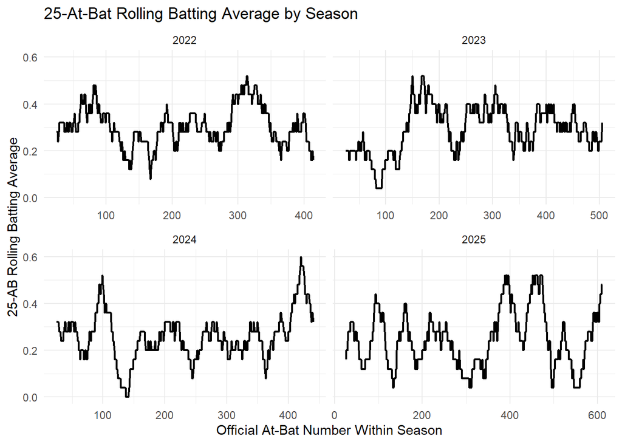

```r
ggplot(
  ab_data %>% filter(!is.na(rolling_ba_25)),
  aes(
    x = season_ab_number,
    y = rolling_ba_25
  )
) +
  geom_line(linewidth = 0.8) +
  facet_wrap(
    ~ game_year,
    scales = "free_x"
  ) +
  labs(
    title = "25-At-Bat Rolling Batting Average by Season",
    x = "Official At-Bat Number Within Season",
    y = "25-AB Rolling Batting Average"
  ) +
  theme_minimal()
```

The 25-at-bat rolling batting-average series show substantial local variation within each season, with periods of relatively high and low observed performance. The magnitude and persistence of these fluctuations also appear to differ across seasons.

However, visible variation in a rolling batting-average series is not, by itself, evidence of a hot-hand effect. Even a sequence of independent hit outcomes with a constant underlying hit probability can produce apparent runs of high and low performance by chance.

The inferential question is therefore whether the observed within-season variation is unusually large relative to what would be expected under an appropriate no-streakiness null model.

# 4 Statistical Evidence for Streakiness

## 4.1 Null Hypothesis

The null model represents a season in which Michael Harris II has a constant underlying probability of recording a hit and official at-bat outcomes are independent.

For season $y$, let

$$\hat p_y =
\frac{\text{Hits}_y}
{\text{Official At-Bats}_y}$$

denote the observed season batting average.

Under the null model, simulated official at-bat outcomes are generated as

$$H_{i,y}^{sim}
\overset{iid}{\sim}
\text{Bernoulli}(\hat p_y).$$

Thus, the baseline hit probability is allowed to differ across seasons, but remains constant across official at-bats within a season.

The null hypothesis does not imply that the observed sequence should be smooth. Independent Bernoulli outcomes can still generate consecutive hits, consecutive non-hits, and temporary periods of high or low rolling batting average by chance.

The inferential question is therefore whether the observed within-season variation in rolling batting average is unusually large relative to the variation generated under this independent Bernoulli benchmark.

## 4.2 Test Streakiness Statistic

To quantify within-season variation in local batting performance, the primary streakiness statistic is defined as the variance of the 25-at-bat rolling batting-average series.

For season $y$, let $R_{y,t}$ denote the 25-at-bat rolling batting average at eligible position $t$. The observed streakiness statistic is

$$T_y^{obs}
=
\operatorname{Var}(R_{y,t}).$$

Larger values of $T_y^{obs}$ indicate greater dispersion in local batting performance across the season, corresponding to more pronounced high and low rolling-performance periods.

The statistic summarizes the magnitude of variation across the full rolling batting-average series rather than relying only on a single maximum or minimum. However, a large observed variance does not by itself establish a hot-hand effect, because substantial rolling variation can also arise from random sequences of independent hit outcomes.

Statistical evidence is therefore obtained by comparing the observed variance with the distribution of the same statistic generated under the season-specific Bernoulli null model.

```r
observed_streakiness <- ab_data %>%
  filter(!is.na(rolling_ba_25)) %>%
  group_by(game_year) %>%
  summarise(
    observed_variance = var(rolling_ba_25),
    .groups = "drop"
  )

observed_streakiness
```

```
## # A tibble: 4 × 2
##   game_year observed_variance
##       <dbl>             <dbl>
## 1      2022           0.00679
## 2      2023           0.00998
## 3      2024           0.0102
## 4      2025           0.0146
```

## 4.3 Monte Carlo Simulation

```r
simulate_streakiness <- function(
  n_ab,
  p_hit,
  window = 25
) {

  simulated_hits <- rbinom(
    n = n_ab,
    size = 1,
    prob = p_hit
  )

  simulated_rolling_ba <- zoo::rollmean(
    simulated_hits,
    k = window,
    fill = NA,
    align = "right"
  )

  simulated_variance <- var(
    simulated_rolling_ba,
    na.rm = TRUE
  )

  return(simulated_variance)
}
```

```r
n_sim <- 5000

set.seed(123)

simulation_results <- season_summary %>%
  select(
    game_year,
    official_ab,
    batting_average
  ) %>%
  tidyr::crossing(
    simulation = seq_len(n_sim)
  ) %>%
  rowwise() %>%
  mutate(
    simulated_variance = simulate_streakiness(
      n_ab = official_ab,
      p_hit = batting_average,
      window = window_size
    )
  ) %>%
  ungroup()
```

The sampling distribution of the streakiness statistic under the null model is not evaluated analytically. Instead, it is approximated using Monte Carlo simulation.

For each season, synthetic official-at-bat sequences are generated from

$$H_{i,y}^{*}
\overset{\mathrm{iid}}{\sim}
\mathrm{Bernoulli}(\hat p_y),$$

while preserving the observed number of official at-bats and the season-specific batting average.

For each simulated season, the same 25-at-bat rolling batting-average procedure used for the observed data is applied. The variance of the resulting rolling series is then calculated,

$$T_y^{*}
=
\operatorname{Var}(R_{y,t}^{*}).$$

This procedure is repeated 5,000 times for each season, producing an empirical null distribution of the streakiness statistic. These distributions represent the amount of rolling-performance variation that would be expected under independent hit outcomes with a constant within-season hit probability.

## 4.4 Monte Carlo P-Values

```r
monte_carlo_results <- simulation_results %>%
  left_join(
    observed_streakiness,
    by = "game_year"
  ) %>%
  group_by(game_year) %>%
  summarise(
    observed_variance = first(observed_variance),

    exceedances = sum(
      simulated_variance >= observed_variance
    ),

    n_simulations = n(),

    monte_carlo_p = (
      exceedances + 1
    ) / (
      n_simulations + 1
    ),

    .groups = "drop"
  )

monte_carlo_results
```

```
## # A tibble: 4 × 5
##   game_year observed_variance exceedances n_simulations monte_carlo_p
##       <dbl>             <dbl>       <int>         <int>         <dbl>
## 1      2022           0.00679        3170          5000      0.634
## 2      2023           0.00998         687          5000      0.138
## 3      2024           0.0102          444          5000      0.0890
## 4      2025           0.0146            0          5000      0.000200
```

For each season, the observed streakiness statistic was compared with its Monte Carlo null distribution. Because larger rolling-variance values represent greater within-season performance fluctuation, evidence against the null model is assessed in the upper tail of the simulated distribution.

The Monte Carlo p-value is calculated as

$$p_{\mathrm{MC}}
=
\frac{
1+\sum_{b=1}^{B}
I(T_{y,b}^{*}\geq T_y^{obs})
}{
B+1
},$$

where $B=5{,}000$ is the number of simulated seasons and $T_{y,b}^{*}$ is the simulated streakiness statistic from Monte Carlo replication $b$.

The finite-simulation correction prevents a p-value of exactly zero when none of the simulated statistics is as large as the observed statistic.

Small Monte Carlo p-values indicate that the observed rolling-performance variation is unusual relative to the season-specific i.i.d. Bernoulli null model. They should not be interpreted as the probability that the null hypothesis is true or as direct proof of a causal hot-hand mechanism.

## 4.5 Null-Envelope Visualization

to see which part of the data is the extreme place?

```r
null_cutoffs <- simulation_results %>%
  group_by(game_year) %>%
  summarise(
    null_95 = quantile(
      simulated_variance,
      probs = 0.95
    ),
    .groups = "drop"
  )

null_cutoffs
```

```
## # A tibble: 4 × 2
##   game_year null_95
##       <dbl>   <dbl>
## 1      2022  0.0118
## 2      2023  0.0114
## 3      2024  0.0110
## 4      2025  0.0102
```

```r
null_plot_data <- null_cutoffs %>%
  left_join(
    observed_streakiness,
    by = "game_year"
  )

null_plot_data
```

```
## # A tibble: 4 × 3
##   game_year null_95 observed_variance
##       <dbl>   <dbl>             <dbl>
## 1      2022  0.0118           0.00679
## 2      2023  0.0114           0.00998
## 3      2024  0.0110           0.0102
## 4      2025  0.0102           0.0146
```

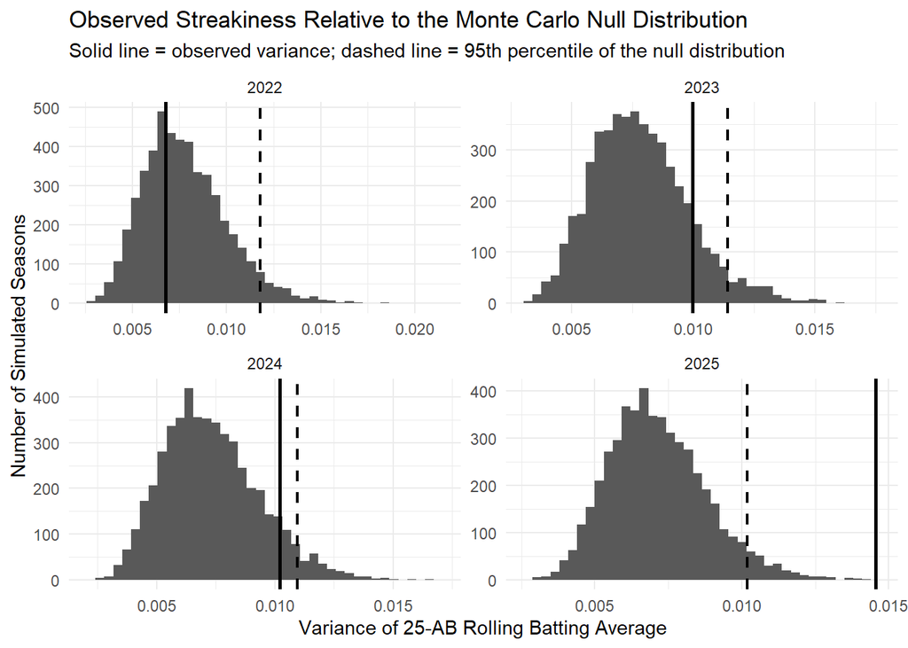

```r
ggplot(
  simulation_results,
  aes(x = simulated_variance)
) +
  geom_histogram(
    bins = 40
  ) +
  geom_vline(
    data = null_plot_data,
    aes(xintercept = null_95),
    inherit.aes = FALSE,
    linetype = "dashed",
    linewidth = 0.8
  ) +
  geom_vline(
    data = null_plot_data,
    aes(xintercept = observed_variance),
    inherit.aes = FALSE,
    linewidth = 1
  ) +
  facet_wrap(
    ~ game_year,
    scales = "free"
  ) +
  labs(
    title = "Observed Streakiness Relative to the Monte Carlo Null Distribution",
    subtitle = "Solid line = observed variance; dashed line = 95th percentile of the null distribution",
    x = "Variance of 25-AB Rolling Batting Average",
    y = "Number of Simulated Seasons"
  ) +
  theme_minimal()
```

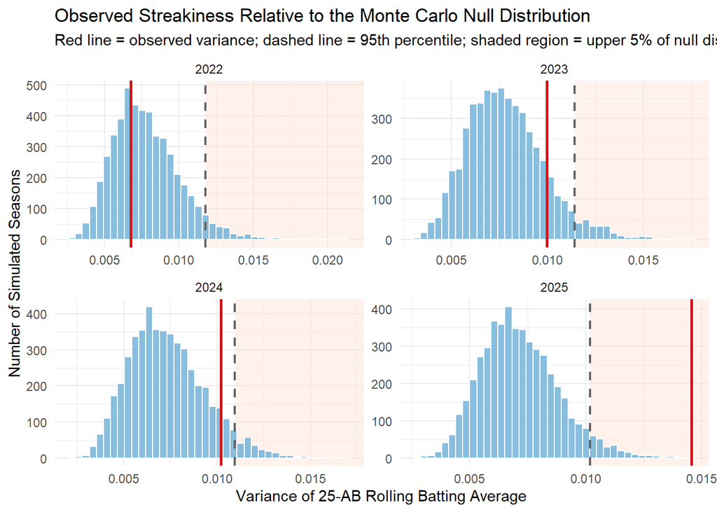

```r
ggplot(
  simulation_results,
  aes(x = simulated_variance)
) +
  geom_rect(
    data = null_plot_data,
    aes(
      xmin = null_95,
      xmax = Inf,
      ymin = -Inf,
      ymax = Inf
    ),
    inherit.aes = FALSE,
    fill = "#FEE0D2",
    alpha = 0.45
  ) +
  geom_histogram(
    bins = 40,
    fill = "#6BAED6",
    color = "white",
    alpha = 0.8
  ) +
  geom_vline(
    data = null_plot_data,
    aes(xintercept = null_95),
    inherit.aes = FALSE,
    linetype = "dashed",
    linewidth = 0.8,
    color = "#636363"
  ) +
  geom_vline(
    data = null_plot_data,
    aes(xintercept = observed_variance),
    inherit.aes = FALSE,
    linewidth = 1,
    color = "#CB181D"
  ) +
  facet_wrap(
    ~ game_year,
    scales = "free"
  ) +
  labs(
    title = "Observed Streakiness Relative to the Monte Carlo Null Distribution",
    subtitle = "Red line = observed variance; dashed line = 95th percentile; shaded region = upper 5% of null distribution",
    x = "Variance of 25-AB Rolling Batting Average",
    y = "Number of Simulated Seasons"
  ) +
  theme_minimal()
```

The Monte Carlo null distributions provide a visual benchmark for the amount of rolling-performance variation expected under independent Bernoulli outcomes.

The 2022 observed statistic lies well within its null distribution, while the 2023 statistic is farther into the upper tail but remains below the 95th-percentile cutoff. The 2024 observed variance lies close to the upper-tail threshold, consistent with suggestive but not conventionally significant evidence of elevated variation.

The strongest departure occurs in 2025. The observed rolling-BA variance lies beyond the 95th-percentile cutoff and exceeds all 5,000 simulated null statistics. This is consistent with the corrected Monte Carlo p-value of approximately 0.0002.

These comparisons indicate that the magnitude of rolling-performance variation in 2025 is highly unusual relative to the specified season-specific i.i.d. Bernoulli null model. They do not, by themselves, identify the mechanism responsible for that departure.

## 4.6 Pointwise Null Envelope

```r
# simulated rolling path

simulate_rolling_path <- function(
  n_ab,
  p_hit,
  window = 25
) {

  simulated_hits <- rbinom(
    n = n_ab,
    size = 1,
    prob = p_hit
  )

  simulated_rolling_ba <- zoo::rollmean(
    simulated_hits,
    k = window,
    fill = NA,
    align = "right"
  )

  tibble(
    season_ab_number = seq_len(n_ab),
    simulated_rolling_ba = simulated_rolling_ba
  )
}
```

```r
# generate simulations

set.seed(123)

rolling_simulations <- season_summary %>%
  select(
    game_year,
    official_ab,
    batting_average
  ) %>%
  tidyr::crossing(
    simulation = seq_len(n_sim)
  ) %>%
  rowwise() %>%
  mutate(
    rolling_path = list(
      simulate_rolling_path(
        n_ab = official_ab,
        p_hit = batting_average,
        window = window_size
      )
    )
  ) %>%
  ungroup() %>%
  select(
    game_year,
    simulation,
    rolling_path
  ) %>%
  tidyr::unnest(rolling_path)
```

```r
null_envelope <- rolling_simulations %>%
  filter(!is.na(simulated_rolling_ba)) %>%
  group_by(
    game_year,
    season_ab_number
  ) %>%
  summarise(
    lower_95 = quantile(
      simulated_rolling_ba,
      probs = 0.025
    ),
    upper_95 = quantile(
      simulated_rolling_ba,
      probs = 0.975
    ),
    .groups = "drop"
  )
```

```r
envelope_plot_data <- ab_data %>%
  filter(!is.na(rolling_ba_25)) %>%
  select(
    game_year,
    season_ab_number,
    rolling_ba_25
  ) %>%
  left_join(
    null_envelope,
    by = c(
      "game_year",
      "season_ab_number"
    )
  )
```

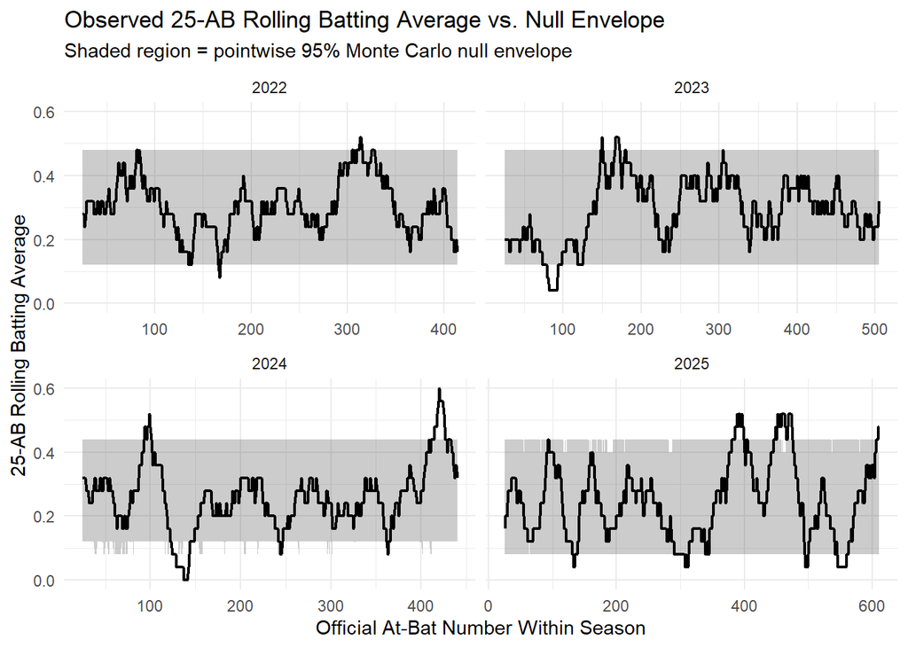

```r
ggplot(
  envelope_plot_data,
  aes(
    x = season_ab_number,
    y = rolling_ba_25
  )
) +
  geom_ribbon(
    aes(
      ymin = lower_95,
      ymax = upper_95
    ),
    alpha = 0.25
  ) +
  geom_line(
    linewidth = 0.8
  ) +
  facet_wrap(
    ~ game_year,
    scales = "free_x"
  ) +
  labs(
    title = "Observed 25-AB Rolling Batting Average vs. Null Envelope",
    subtitle = "Shaded region = pointwise 95% Monte Carlo null envelope",
    x = "Official At-Bat Number Within Season",
    y = "25-AB Rolling Batting Average"
  ) +
  theme_minimal()
```

To visualize where the observed rolling batting-average trajectory differs from patterns commonly generated under the null model, pointwise Monte Carlo envelopes were constructed.

For each season and each eligible official-at-bat position, the 2.5th and 97.5th percentiles of the simulated 25-at-bat rolling batting averages were calculated. These quantiles form a pointwise 95% null envelope around the rolling-performance trajectories expected under the season-specific i.i.d. Bernoulli model.

Observed values outside the envelope identify local periods that appear unusual relative to the null benchmark. However, the envelope is pointwise rather than simultaneous. Because many positions are examined within each season, an individual crossing should not be interpreted as a standalone 5% significance test.

Formal season-level inference therefore remains based on the Monte Carlo variance statistic and its corresponding p-value. The pointwise envelope is used primarily to visualize and localize the performance patterns underlying the season-level results.

## 4.7 Year-by-Year Results

The Monte Carlo analysis reveals substantial differences in the magnitude of within-season rolling-performance variation across seasons.

In 2022, the observed rolling-BA variance was well within the range expected under the season-specific Bernoulli null model ($p_{\mathrm{MC}} = 0.634$). Thus, the observed variation provides little evidence of a departure from the independent, constant-probability benchmark.

The 2023 season exhibited greater rolling-performance variation, but the observed statistic remained compatible with the null distribution ($p_{\mathrm{MC}} = 0.138$).

The 2024 observed variance was farther into the upper tail of its null distribution ($p_{\mathrm{MC}} = 0.089$). This provides suggestive evidence of elevated within-season variation, although the result does not cross the conventional 0.05 threshold.

The strongest departure occurred in 2025. None of the 5,000 simulated seasons produced a rolling-BA variance as large as the observed value. After applying the finite-simulation correction, the Monte Carlo p-value was approximately $0.0002$. The magnitude of the observed 2025 rolling-performance variation was therefore highly unusual relative to the specified season-specific i.i.d. Bernoulli null model.

These results provide evidence about departures from the specified no-streakiness benchmark rather than establishing a causal hot-hand mechanism. Time-varying opponent quality, pitcher matchups, injuries, platoon effects, and other contextual factors could also generate departures from a constant-probability Bernoulli model.

Because four season-specific tests were conducted, Holm-adjusted p-values were also examined as a multiple-testing sensitivity check.

```r
monte_carlo_results <- monte_carlo_results %>%
  mutate(
    holm_p = p.adjust(
      monte_carlo_p,
      method = "holm"
    )
  )

monte_carlo_results
```

```
## # A tibble: 4 × 6
##   game_year observed_variance exceedances n_simulations monte_carlo_p   holm_p
##       <dbl>             <dbl>       <int>         <int>         <dbl>    <dbl>
## 1      2022           0.00679        3170          5000      0.634    0.634
## 2      2023           0.00998         687          5000      0.138    0.275
## 3      2024           0.0102          444          5000      0.0890   0.267
## 4      2025           0.0146            0          5000      0.000200 0.000800
```

# 5 Main Findings

The analysis yields three main findings.

First, Michael Harris II’s 25-at-bat rolling batting average exhibits substantial local variation across all four seasons. Periods of relatively high and low observed performance are therefore visible in the raw performance trajectories, although such patterns can also arise from random sequences of independent hit outcomes.

Second, the magnitude of this variation differs substantially across seasons when compared with season-specific Monte Carlo null distributions. The 2022 and 2023 observed statistics were compatible with the independent Bernoulli benchmark, while the 2024 statistic was farther into the upper tail of its null distribution ($p_{\mathrm{MC}} = 0.089$).

Third, the strongest departure occurred in 2025. None of the 5,000 simulated null seasons produced a 25-at-bat rolling-BA variance as large as the observed value, yielding a finite-simulation-corrected Monte Carlo p-value of approximately $0.0002$.

Taken together, the results indicate that the 2025 batting sequence contained substantially more rolling-performance variation than expected under the specified season-specific i.i.d. Bernoulli model. This finding identifies an unusually variable performance pattern, but does not by itself establish a causal hot-hand mechanism.

# 6 Limitations

The analysis should be interpreted relative to the assumptions of the specified null model.

First, the season-specific i.i.d. Bernoulli model assumes that the underlying hit probability remains constant within each season and that official at-bat outcomes are independent. Real batting opportunities vary with pitcher quality, handedness, game environment, injuries, and other contextual factors. Consequently, rejection of this simplified null model does not uniquely identify a hot-hand mechanism.

Second, the season-level hit probability is unknown and is replaced by the observed batting average. The Monte Carlo distributions therefore condition on an estimated season-specific probability rather than propagating uncertainty in that parameter.

Third, the primary analysis depends on a 25-at-bat rolling window and on rolling-BA variance as the streakiness statistic. The window length is an analytical choice, and variance measures the magnitude of local performance variation rather than temporal persistence directly. Alternative window lengths and streakiness statistics should therefore be examined as robustness checks.

Fourth, adjacent rolling batting averages share most of their underlying at-bats and are consequently highly dependent. The Monte Carlo procedure reproduces this overlapping-window structure in every simulated season, but individual rolling observations should not be interpreted as independent measurements.

Finally, the 95% rolling-BA null envelopes are pointwise rather than simultaneous. Individual crossings are therefore descriptive indicators of locally unusual performance rather than standalone significance tests.

More broadly, the analysis is observational. It identifies departures from a specified no-streakiness statistical benchmark but does not estimate a randomized or causal effect of being in a “hot” state.

# 7 Conclusion

This study examined whether Michael Harris II’s within-season batting performance exhibited more temporal variation than would be expected under a season-specific no-streakiness benchmark. Pitch-level Statcast data from 2022 through 2025 were reconstructed into official at-bats, represented as binary hit outcomes, and summarized using 25-at-bat rolling batting averages. The variance of each season’s rolling series was then compared with empirical null distributions generated from 5,000 season-specific Bernoulli simulations.

The strength of evidence differed substantially across seasons. The 2022 and 2023 performance trajectories were broadly compatible with the independent Bernoulli benchmark, while 2024 showed suggestive evidence of elevated rolling-performance variation. The strongest departure occurred in 2025: none of the 5,000 simulated null seasons produced a rolling-BA variance as large as the observed value, corresponding to a finite-simulation-corrected Monte Carlo p-value of approximately 0.0002.

These findings indicate that Harris’s 2025 batting sequence contained substantially more local performance variation than expected under the specified season-specific i.i.d. Bernoulli model. They do not, however, establish that the variation was generated by a causal or persistent hot-hand mechanism. Robustness analyses and baseball-context analyses are therefore needed to determine whether the result persists under alternative statistical specifications and whether changes in pitching environment, swing decisions, contact quality, or other observable factors coincide with the unusual performance periods.